# Relevant Factors for Flexibility

First we load in the various data frames.

```r
library(dplyr)
autotyp_register <- read.csv('../autotyp-data-master/data/Register.csv', na.strings='') %>%
  rename(LanguageAutotyp = Language) %>%
  select(LID, ISO639.3, Glottocode, SubBranch, Area, LanguageAutotyp, LanguageAlternativeNames)
wals_register <- read.csv('../autotyp-data-master/data/WALS_register.csv', na.strings='') %>%
  rename(LanguageWALS = name, WALSCode = wals_code, Glottocode = glottocode) %>%
  select(WALSCode, Glottocode)
```

Next, we need the feature data from Autotyp and WALS.

Clause_word_order_adjusted.csv contains the original Autotyp data for clausal constituent order, with adjusted header names. For now, the relevant fields are WordOrderSPVBasicLex (the “canonical” constituent order—SOV, SVO, VSO, VOS, OSV, OVS or “free”) and WordOrderSPVLexFlexible (“free”, “flexible” or “rigid”).

```r
autotyp_clause_order <- read.csv('../autotyp-data-master/data/Clause_word_order_adjusted.csv', na.strings='') %>%
  select(LID, WordOrderSPVBasicLex, WordOrderSPVLexFlexible)
```

From WALS, we are interested in (1) whether the language is head-marking, dependent-marking, dual-marking, or does not have marking; (2) whether person is marked on the verb—this may be agent-only, patient-only, both, or none; and (3) whether or not the language has cases.

Regarding cases, languages are mapped to 1 or 0 depending on their coding in WALS. Language listed as having “No morphological case-marking” or “Exclusively borderline case-marking” are coded as 0; this is because we are interested in languages that mark *core* arguments. All other values are coded as 1. This is of course a very coarse heuristic, as languages like English, which is coded as having 2 cases, will receive a 1 despite our intuition that English on the whole does not case-mark.

```r
has_cases <- function(x){
  code <- toString(x)
  if(is.na(x)){ return(NA); }
  if(code == 'No morphological case-marking'){ return(0)}
  if(code == 'Exclusively borderline case-marking'){ return(0)}
  return(1);
}
has_prodrop <- function(x){
  code <- toString(x)
  if(is.na(x)){ return(NA); }
  if(code == 'Obligatory pronouns in subject position'){ return(0)}
  if(code == 'Subject pronouns in different position'){ return(0)}
  if(code == 'Mixed'){ return(2)}
  return(1);
}
wals_dependent_head <- read.csv('../autotyp-data-master/data/WALS_marking.csv', na.strings='') %>% rename(WALSCode = ID, Marking = Name) %>% select(WALSCode, Marking)
wals_person_marking <- read.csv('../autotyp-data-master/data/WALS_person_marking.csv', na.strings='') %>% rename(WALSCode = ID, VerbPersonMarking = Name) %>% select(WALSCode, VerbPersonMarking)
wals_has_case <- read.csv('../autotyp-data-master/data/WALS_cases.csv', na.strings='') %>% rename(WALSCode = ID, NumCases = Name) %>% select(WALSCode, NumCases) %>% mutate(CaseMarking = mapply(function(x) has_cases(x), NumCases))
wals_has_prodrop <- read.csv('../autotyp-data-master/data/WALS_prodrop.csv', na.strings='') %>% rename(WALSCode = ID, HasProdrop = Name) %>% select(WALSCode, HasProdrop)
```

Finally, we also want the WALS constituent order data for comparison with Autotyp.

```r
wals_clause_order <- read.csv('../autotyp-data-master/data/WALS_clause_order.csv', na.strings='') %>%
  rename(WALSOrder = Name, WALSCode = ID, LanguageWALS = Language,  WALSReference = References) %>%
  select(WALSCode, WALSOrder, LanguageWALS, WALSReference)
wals_two_orders <- read.csv('../autotyp-data-master/data/WALS_two_orders.csv', na.strings='') %>%
  rename(WALSTwoOrder = Name, WALSCode = ID, LanguageWALS = Language,  WALSReference = References) %>%
  select(WALSCode, WALSTwoOrder)
```

```r
register <- merge(wals_register, autotyp_register, 'Glottocode')
factors <- merge(wals_dependent_head, wals_person_marking, 'WALSCode')
factors <- merge(wals_has_case, factors, 'WALSCode')
flexibility_data <- merge(register, autotyp_clause_order, 'LID')
flexibility_data <- merge(wals_clause_order, flexibility_data, 'WALSCode', all = TRUE)
flexibility_data <- merge(wals_two_orders, flexibility_data, 'WALSCode', all = TRUE)
flexibility_data <- merge(wals_has_prodrop, flexibility_data, 'WALSCode', all = TRUE)
flexibility_data <- merge(factors, flexibility_data, 'WALSCode', all.y = TRUE)
```

Finally, output the data to a file.

```r
flexibility_data_out <- flexibility_data %>% select(LID, WALSCode, Glottocode, ISO639.3, LanguageAutotyp, LanguageWALS, Area, SubBranch, WALSOrder, WALSTwoOrder, WordOrderSPVBasicLex, WordOrderSPVLexFlexible, Marking, CaseMarking, VerbPersonMarking, HasProdrop) %>% group_by(LID)
write.csv(flexibility_data_out, file="flexibility_data.csv",
          row.names=FALSE)
```

In addition to our flexibility factors, we also want to know where Autotyp and WALS disagree, even if the other data is not complete. Thus, we used a full outer join for the “factors”, and a partial inner join for the “order” data.

```r
factors_full <- merge(wals_dependent_head, wals_person_marking, 'WALSCode', all = TRUE)
factors_full <- merge(wals_has_case, factors_full, 'WALSCode', all = TRUE)
flexibility_data_full <- merge(register, autotyp_clause_order, 'LID')
flexibility_data_full <- merge(wals_clause_order, flexibility_data_full, 'WALSCode')
flexibility_data_full <- merge(wals_two_orders, flexibility_data_full, 'WALSCode', all.y = TRUE)
flexibility_data_full <- merge(factors, flexibility_data_full, 'WALSCode', all.y = TRUE)
```

```r
discrepancies <- flexibility_data_full %>% select(LID, ISO639.3, WALSCode, Glottocode, LanguageAutotyp, LanguageWALS, LanguageAlternativeNames, Area, WALSOrder, WALSTwoOrder, WordOrderSPVBasicLex, WordOrderSPVLexFlexible) %>% filter((as.character(WordOrderSPVBasicLex) != as.character(WALSOrder)) & (WALSOrder != "No dominant order" | WordOrderSPVBasicLex != "free"))

discrepancies

write.csv(discrepancies, file="discrepancies.csv",
          row.names=FALSE)
```

[output not shown]

```r
# library
library(treemap)

# Build Dataset
group=c(rep("Agree\nn=266",1),rep("Disagree\nn=38",3),rep("Disagree\n(Definitional)\nn=8",1))
subgroup=c("","Same n=28","Same n=28","Unclear n=10", "")
subsubgroup=c("", "No dominant order\nn=19", "Has dominant order\nn=9","", "")
value=c(150,19,9,10,8)
color=c("#f01d6a", "#00ceb6", "#00bfa9", "#01ae9a", "#fdd739")
data=data.frame(group,subgroup,subsubgroup, value,color)
```

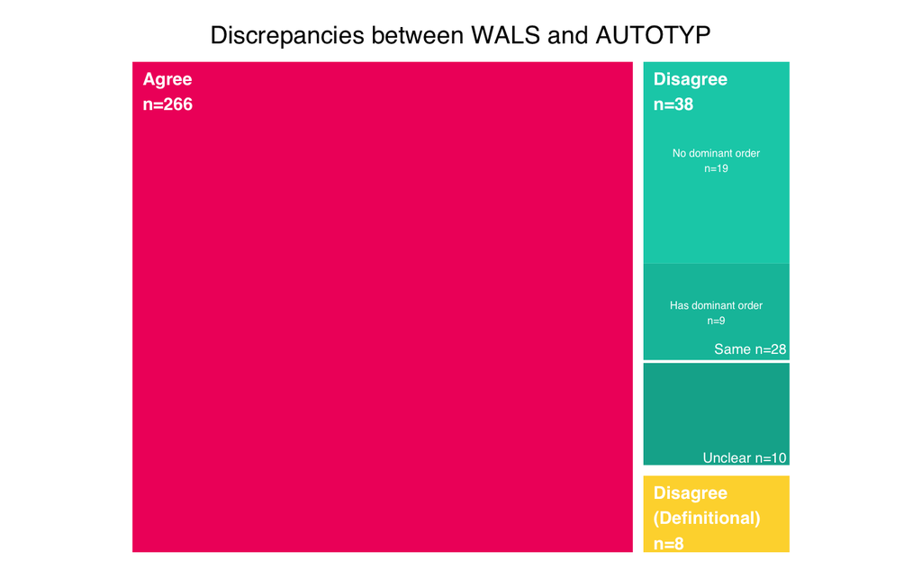

```r
# treemap
treemap(data,
            index=c("group","subgroup", "subsubgroup"),
            vSize="value",
            vColor="color",
            type="color",
            border.col=c("white","white", "white"),
            border.lwds=c(8,2,0),
            fontcolor.labels=c("white","white", "white"),
            algorithm="pivotSize",
            align.labels=list(
              c("left", "top"),
              c("right", "bottom"),
              c("center", "center")
            ),
            aspRatio=4/3,
            overlap.labels=0.5,
            inflate.labels=F,
            bg.labels=c("transparent"),
            ymod.labels = c(-0.08, 0.03, 0),
            xmod.labels = c(0.08, -0.03, 0),
            fontsize.labels = c(10,8,6),
            title="Discrepancies between WALS and AUTOTYP"
            )
```

```r
# These are just being saved in case we need them

#autotyp_np_structure <- read.csv('../autotyp-data-master/data/NP_Structure.csv', na.strings='') %>% select(LID, NPMarking.binned4, NPWordOrder)  %>% filter(!is.na(NPMarking.binned4) & !is.na(NPWordOrder))

#bib <- read.csv('../autotyp-data-master/data/Bibliography.csv', na.strings='') %>% select(LID, Author, Year)
#bib2 <- aggregate(Author~LID, bib, paste, collapse="//")
#bib2 <- merge(aggregate(Year~LID, bib, paste, collapse="//"), bib2, 'LID')
```